# **Ταξινόμηση είδους ταινίας βάσει πλοκής**

```python
import re
import string
from bs4 import BeautifulSoup
from nltk.stem import PorterStemmer

# Create a Porter stemmer object
stemmer = PorterStemmer()

# Συνάρτηση για τον υπόλοιπο καθαρισμό του κειμένου
def preprocess_text(text):
    # Μετατροπή σε μικρά γράμματα
    text = text.lower()

    # Αφαίρεση (\'s)
    text = re.sub(r"\'s", "", text)

    # Αφαίρεση καινούριας γραμμής (\r\n)
    text = re.sub(r"\r\n", "", text)

    # Αφαίρεση του κειμένου που βρίσκεται μέσα σε παρένθεση ()
    text = re.sub(r"\([^()]*\)", "", text)

    # Αφαίρεση αριθμών
    text = re.sub(r"\d+", "", text)

    # Αφαίρεση σημείων στίξης και ειδικών χαρακτήρων
    text = text.translate(str.maketrans("", "", string.punctuation))

    # Αφαίρεση HTML ετικετών
    text = BeautifulSoup(text, "html.parser").get_text()

    # Αφαίρεση περιττών κενών
    text = re.sub(r"\s+", " ", text).strip()

    # Apply stemming
    stemmed_text = ' '.join([stemmer.stem(word) for word in text.split()])

    return stemmed_text

filtered_movie_data.loc[:, 'plot'] = filtered_movie_data['plot'].apply(preprocess_text)
filtered_movie_data.head(5)
```

|  | genre | plot |
| --- | --- | --- |
| 6 | western | film open two bandit break railroad telegraph ... |
| 7 | comedy | film famili move suburb hope quiet life thing ... |
| 11 | action | film featur train travel rocki hold creat two ... |
| 14 | comedy | head basebal game nearbi ballpark sport fan mr... |
| 15 | comedy | plot black woman go dentist toothach given lau... |

Παρατηρούμε πως με τον καθαρισμό του κειμένου, σύμφωνα με τον παρακάτω κώδικα, μειώθηκε ο μέσος όρος των λέξεων ανά περιγραφή της πλοκής της ταινίας.Το ίδιο παρατηρήθηκε και για τη τυπική απόκλιση των λέξεων.

```python
filtered_movie_data = filtered_movie_data.copy()
filtered_movie_data['plot_length'] = filtered_movie_data['plot'].str.split().str.len()

average_words_per_plot = filtered_movie_data['plot_length'].mean()
standard_deviation = filtered_movie_data['plot_length'].std()
max_word_count = filtered_movie_data['plot_length'].max()

print("Average number of words per plot:", int(average_words_per_plot))
print("Standard deviation of the words:", int(standard_deviation))
print("Max word count of a plot:", max_word_count)
```

```
Average number of words per plot: 210
Standard deviation of the words: 170
Max word count of a plot: 2804
```

Μπορεί να παρατηρηθεί ότι, η μεταβλητή του είδους της ταινίας (genre) είναι κατηγορική μεταβλητή και ειδικότερα ονομαστική κατηγορική μεταβλητή (nominal categorical variable). Προκειμένου να μπορεί να αποτελέσει έγκυρη είσοδο, θα πρέπει να μετατραπεί σε αριθμητική μεταβλητή. Το τελευταίο, πραγματοποιείται μετατρέποντας τη σε Dummy Μεταβλητές (Dummy Variables) ή εναλλακτικά σε Κωδικοποίηση One-hot (One-hot Encoding). Ειδικότερα, αυτό που γίνεται είναι ότι δοθέντος μιας μεταβλητής με k επίπεδα, κάθε επίπεδο μετατρέπεται σε ένα νέο χαρακτηριστικό με την τιμή 1 (TRUE) εκεί που εμφανίζεται η τιμή του συγκεκριμένου επιπέδου και 0 (FALSE) αλλού. Η διαδικασία αυτή μπορεί να πραγματοποιηθεί μέσω της συνάρτησης get_dummies του pandas Dataframe. Τέλος, η μεταβλητή προς πρόβλεψη θα διατηρήθει σε μια ξεχωριστή μεταβλητή, ώστε να μπορεί να αξιοποιηθεί αργότερα.

```python
# Δημιούργησε τα Dummy Variables
categorical_features = ['genre']
dummy_variable = pd.get_dummies(filtered_movie_data[categorical_features])

# Διατήρησε την μεταβλητή προς πρόβλεψη σε ξεχωριστή μεταβλητή
y = filtered_movie_data['genre']

# Αφαίρεσε τις παλιές ονομαστικές κατηγορικές μεταβλητές και την μεταβλητή προς προβλεψη από το σύνολο δεδομένων
variables_to_be_deleted = ['genre']
filtered_movie_data_with_dummies = filtered_movie_data.drop(variables_to_be_deleted, # μεταβλητές προς διαγραφή
                                              axis=1 # διαγραφή από τις στήλες του dataframe
                                             )

# βάλε τις dummy variables στο σύνολο δεδομένων
filtered_movie_data_with_dummies = pd.concat([filtered_movie_data_with_dummies, dummy_variable], axis=1)

# δες το αποτέλεσμα
filtered_movie_data_with_dummies.head(5)
```

|  | plot | plot_length | genre_action | genre_adventure | genre_animation | genre_biography | genre_comedy | genre_crime | genre_drama | genre_family | genre_horror | genre_musical | genre_mystery | genre_romance | genre_science fiction | genre_thriller | genre_war | genre_western |
| --- | --- | --- | --- | --- | --- | --- | --- | --- | --- | --- | --- | --- | --- | --- | --- | --- | --- | --- |
| 6 | film open two bandit break railroad telegraph ... | 124 | False | False | False | False | False | False | False | False | False | False | False | False | False | False | False | True |
| 7 | film famili move suburb hope quiet life thing ... | 19 | False | False | False | False | True | False | False | False | False | False | False | False | False | False | False | False |
| 11 | film featur train travel rocki hold creat two ... | 25 | True | False | False | False | False | False | False | False | False | False | False | False | False | False | False | False |
| 14 | head basebal game nearbi ballpark sport fan mr... | 56 | False | False | False | False | True | False | False | False | False | False | False | False | False | False | False | False |
| 15 | plot black woman go dentist toothach given lau... | 25 | False | False | False | False | True | False | False | False | False | False | False | False | False | False | False | False |

Σε αυτό το σημείο, μπορεί να γίνει διαχωρισμός με τυχαία δειγματοληψία του συνόλου δεδομένων σε σύνολο δεδομένων εκπαίδευσης (train set) και σύνολο δεδομένων δοκιμής (test set), με αναλογία 70% και 30% του αρχικού συνόλου δεδομένων, αντίστοιχα. Έτσι, θα πραγματοποιηθεί εκπαίδευση των μεθόδων με τα δεδομένα εκπαίδευσης και στην συνέχεια θα διεκπεραιωθεί η αξιολόγηση τους στο σύνολο δεδομένων δοκιμής. Με αυτόν τον τρόπο, η μέθοδος αξιολογείται σύμφωνα με δεδομένα, που δεν έχει ξανα δει και συνεπώς η αποτίμηση της απόδοσης δεν εμπεριέχει προκαταληψη (bias). Για τον διαχωρισμό, που περιγράφηκε προηγουμένως, θα χρησιμοποιηθεί η συνάρτηση του module model_selection της βιβλιοθήκης scikit-learn με όνομα train_test_split.

```python
import sklearn.model_selection

# Χώρισε το σύνολο δεδομένων σε σύνολο δεδομένων εκπαίδευσης και δοκιμής με τυχαία δειγματοληψία σε αναλογία 70% και 30% αντίστοιχα
test_size = 0.3
x_train, x_test, y_train, y_test = sklearn.model_selection.train_test_split(filtered_movie_data_with_dummies.values,
                                                                            y,
                                                                            test_size=test_size, # μέγεθος δεδομένων δοκιμής = test_size
                                                                            shuffle=True, # ανακάτεψε τα
                                                                            random_state=42 # για επαναληψιμότητα
                                                                           )
print("Number of Observations in the Data set:" , filtered_movie_data_with_dummies.values.shape[0])
print("Number of Observations in Train set:", x_train.shape[0])
print("Number of Observations in Test set:" , x_test.shape[0])
```

```
Number of Observations in the Data set: 26877
Number of Observations in Train set: 18813
Number of Observations in Test set: 8064
```

```python
from tensorflow.keras.preprocessing.text import Tokenizer
from tensorflow.keras.preprocessing.sequence import pad_sequences

# Μετατροπή λέξεων σε ακολουθίες ακεραίων
tokenizer = Tokenizer(num_words=10000)
tokenizer.fit_on_texts([str(sentence) for sentence in x_train])  # Convert to strings
x_train_seq = tokenizer.texts_to_sequences([str(sentence) for sentence in x_train])  # Convert to strings
x_test_seq = tokenizer.texts_to_sequences([str(sentence) for sentence in x_test])  # Convert to strings

# Pad τις ακολουθίες στο μέγιστο μήκος
max_sequence_length = 3000
x_train_padded = pad_sequences(x_train_seq, maxlen=max_sequence_length)
x_test_padded = pad_sequences(x_test_seq, maxlen=max_sequence_length)

print("Padded Training Sequences:")
print(x_train_padded)
print("Padded Test Sequences:")
print(x_test_padded)

print('x_train_padded shape:', x_train_padded.shape)
print('x_test_padded shape:', x_test_padded.shape)
```

```
Padded Training Sequences:
[[0 0 0 ... 1 1 1]
 [0 0 0 ... 2 1 1]
 [0 0 0 ... 1 1 1]
 ...
 [0 0 0 ... 1 1 1]
 [0 0 0 ... 1 1 1]
 [0 0 0 ... 1 1 1]]
Padded Test Sequences:
[[0 0 0 ... 1 1 1]
 [0 0 0 ... 1 1 1]
 [0 0 0 ... 1 1 1]
 ...
 [0 0 0 ... 1 1 1]
 [0 0 0 ... 1 1 1]
 [0 0 0 ... 1 1 1]]
x_train_padded shape: (18813, 3000)
x_test_padded shape: (8064, 3000)
```

```python
from sklearn.preprocessing import LabelEncoder
from tensorflow.keras.utils import to_categorical

# Κωδικοποίηση των ετικετών συμβολοσειρών σε ακέραιες τιμές
label_encoder = LabelEncoder()
y_train_encoded = label_encoder.fit_transform(y_train)

# Μετατροπή των κωδικοποιημένων ετικετών σε διανύσματα κωδικοποίησης one-hot
num_classes = len(label_encoder.classes_)
y_train_onehot = to_categorical(y_train_encoded, num_classes=num_classes)
```

Η παραπάνω κωδικοποίηση πραγματοποείται για την έξοδο του μοντέλου που θα δημιουργηθεί παρακάτω. Σε προβλήματα ταξινόμησης πολλαπλών κλάσεων όπως το συγκεκριμένο, το επίπεδο εξόδου του νευρωνικού δικτύου μπορεί να έχει πολλούς κόμβους, καθένας από τους οποίους αντιπροσωπεύει μια κλάση - σε εμάς είδος ταινίας. Η κωδικοποίηση One-hot επιτρέπει την αναπαράσταση της αληθινής κλάσης ως δυαδικό διάνυσμα για εκπαίδευση και αξιολόγηση.

## *Κατασκευή, Εκπαίδευση και Αξιολόγηση του Αναδρομικού Νευρωνικού Δικτύου*

Σε αυτό το σημείο μπορεί να πραγματοποιηθεί η κατασκευή, εκπαίδευση και αξιολόγηση του Αναδρομικού Νευρωνικού Δικτύου. Συγκεκριμένα, για την επίλυση του προβλήματος της ταξινόμησης των ταινιών βάσει είδους, θα χρησιμοποιηθεί ένα Long Short-Term Memory (LSTM) τεχνητό νευρωνικό δίκτυο, το οποίο θα κατασκευαστεί μέσω του Functional API. Ειδικότερα, τα μοντέλα ορίζονται δημιουργώντας και συνδέοντας κατάλληλα τα επιθυμητά επίπεδα, ενώ στην συνέχεια γίνεται η δημιουργία του μοντέλου ορίζοντας από τα συνδεδεμένα επίπεδα ποιο θα αποτελεί την είσοδο και ποιό την έξοδο, καθώς ταυτόχρονα υποστηρίζει και πολλαπλές εισόδους και εξόδους. Η δημιουργία του μοντέλου γίνεται χρησιμοποιώντας την συνάρτηση Model που βρίσκεται στο module keras της βιβλιοθήκης Tensorflow.

```python
import tensorflow as tf

# Δημιουργία του επιπέδου εισόδου
input_layer = tf.keras.Input(shape=(3000,), dtype="int32") # Είσοδος μεγέθους 3000

# Δημιουργία επιππέδου Embedding
x = tf.keras.layers.Embedding(input_dim=10000, # διαστάσεις εισόδου
                              output_dim=32, # διαστάσεις εξόδου
                              embeddings_regularizer=tf.keras.regularizers.l2(0.01))(input_layer) #regularization L2

# Δημιουργία LSTM τεχνητού νευρωνικού δικτύου
x = tf.keras.layers.LSTM(units=32, # χρησιμοποίησε 32 νευρώνες σε κάθε εσωτερικό κελί
                         return_sequences=True)(x)  # return_sequences=True

# Δημιουργία LSTM τεχνητού νευρωνικού δικτύου με recurrent dropout
x = tf.keras.layers.LSTM(units=32, recurrent_dropout=0.5)(x)  # ρυθμός recurrent dropout 0.5

# Δημιουργία Επιπέδου ταξινόμησης
out = tf.keras.layers.Dense(units=num_classes, activation="softmax")(x)

# Δημουργία τελικού Μοντέλου
lstm_model = tf.keras.Model(inputs=input_layer, outputs=out)
```

Αρχικά, το Input Layer ορίζει το σχήμα και τον τύπο δεδομένων της εισόδου στο μοντέλο. Σε αυτήν την περίπτωση, το σχήμα εισόδου είναι (3000,), δηλαδή το μοντέλο αναμένει πλοκές ταινιών μήκους 3000 λέξεων. Αμέσως μετά, Embedding Layer μετατρέπει τις ακέραιες ακολουθίες εισόδου σε dense vector representations. Αντιστοιχίζει κάθε ακέραια τιμή σε ένα dense vector μεγέθους output_dim, σε αυτήν την περίπτωση, 32. Η παράμετρος input_dim καθορίζει το μέγεθος του λεξιλογίου και το embeddings_regularizer εφαρμόζει regularization L2 στα βάρη του embedding με ρυθμό 0,01, ώστε να αποφευχθεί το overfitting. Έπειτα προστίθεται ένα LSTM Layer. Η παράμετρος units καθορίζει τον αριθμό των κρυμμένων νευρώνων LSTM στο επίπεδο. Βάζοντας τη παράμετρο return_sequences=True σημαίνει ότι το επίπεδο θα επιστρέψει ολόκληρη την ακολουθία των κρυφών καταστάσεων και όχι μόνο την τελευταία. Αυτό είναι αναγκαίο διότι προστίθεται ένα ακόμα LSTM Layer στο μοντέλο, με τον ίδιο αριθμό μονάδων (32) με το προηγούμενο επίπεδο. Ωστόσο, αυτό το επίπεδο περιλαμβάνει επίσης reccurent dropout, η οποία βοηθά στην αποφυγή overfitting σε επαναλαμβανόμενα νευρωνικά δίκτυα θέτοντας τυχαία ένα κλάσμα των εισόδων στο 0 κατά τη διάρκεια της εκπαίδευσης. Η παράμετρος recurrent_dropout ελέγχει το ποσοστό dropout, το οποίο έχει οριστεί σε 0,5, που σημαίνει ότι το 50% των input θα απορριφθεί κατά τη διάρκεια της εκπαίδευσης. Τέλος, το Dense Layer είναι ένα πλήρως συνδεδεμένο επίπεδο που αντιστοιχίζει την έξοδο του προηγούμενου επιπέδου με τον αριθμό των κλάσεων εξόδου (num_classes). Η συνάρτηση ενεργοποίησης έχει οριστεί σε "softmax", η οποία παράγει μια κατανομή πιθανότητας στις κλάσεις, υποδεικνύοντας την πιθανότητα κάθε κλάσης.

```python
# Δες την αρχιτεκτονική που δημιουργήθηκε
lstm_model.summary()
```

```
Model: "model"
_________________________________________________________________
 Layer (type)                Output Shape              Param #
=================================================================
 input_1 (InputLayer)        [(None, 3000)]            0

 embedding (Embedding)       (None, 3000, 32)          320000

 lstm (LSTM)                 (None, 3000, 32)          8320

 lstm_1 (LSTM)               (None, 32)                8320

 dense (Dense)               (None, 16)                528

=================================================================
Total params: 337,168
Trainable params: 337,168
Non-trainable params: 0
_________________________________________________________________
```

- input_1 (InputLayer): το Input Layer δεν έχει εκπαιδεύσιμες παραμέτρους.
- embedding (Embedding): Το Embedding Layer έχει 320.000 παραμέτρους. Αντιστοιχίζει κάθε ευρετήριο λέξης σε ένα διάνυσμα embedding 32 διαστάσεων.
- lstm (LSTM): Το πρώτο επίπεδο LSTM έχει 8.320 παραμέτρους.
- lstm_1 (LSTM): Το δεύτερο επίπεδο LSTM έχει 8.320 παραμέτρους και επιστρέφει ένα μόνο διάνυσμα, την τελευταία κρυφή κατάσταση.
- dense (Dense): Το Dense Layer έχει 528 παραμέτρους. Παράγει την τελική έξοδο που αντιστοιχεί στον αριθμό των κλάσεων.

```python
lstm_model.compile(loss='categorical_crossentropy', optimizer='rmsprop', metrics=['accuracy'])
```

```python
epochs, batch_size = 10, 64
history = lstm_model.fit(x_train_padded,
                         y_train_onehot,
                         epochs=epochs,
                         batch_size=batch_size,
                         validation_split=0.1,
                         verbose=1)
```

```python
# Κωδικοποίηση των ετικετών test ως αριθμητικές τιμές
label_encoder = LabelEncoder()
y_test_encoded = label_encoder.fit_transform(y_test)

# Ο αριθμός των μοναδικών κλάσεων
num_classes = len(label_encoder.classes_)

# Μετατροπή σε one-hot κωδικοποίηση
y_test_onehot = to_categorical(y_test_encoded, num_classes=num_classes)

# Evaluation του μοντέλου στο test set
test_loss, test_accuracy = lstm_model.evaluate(x_test_padded, y_test_onehot)

print("Test Loss:", test_loss)
print("Test Accuracy:", test_accuracy)
```

```
Test Loss: 0.028523199260234833
Test Accuracy: 1.0
```

```
The Mean Absolute Error of the Test Data is 0.0
The prediction accuracy is: 1.0
              precision    recall  f1-score   support

           0       1.00      1.00      1.00       535
           1       1.00      1.00      1.00       154
           2       1.00      1.00      1.00       258
           3       1.00      1.00      1.00        54
           4       1.00      1.00      1.00      2159
           5       1.00      1.00      1.00       158
           6       1.00      1.00      1.00      2756
           7       1.00      1.00      1.00        96
           8       1.00      1.00      1.00       370
           9       1.00      1.00      1.00       144
          10       1.00      1.00      1.00        83
          11       1.00      1.00      1.00       276
          12       1.00      1.00      1.00       244
          13       1.00      1.00      1.00       448
          14       1.00      1.00      1.00        78
          15       1.00      1.00      1.00       251

    accuracy                           1.00      8064
   macro avg       1.00      1.00      1.00      8064
weighted avg       1.00      1.00      1.00      8064
```

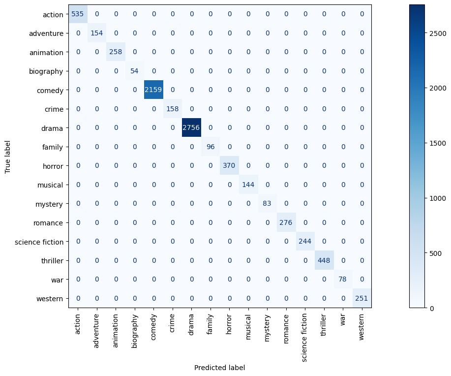

```python
from sklearn.metrics import confusion_matrix, ConfusionMatrixDisplay, accuracy_score, classification_report, mean_absolute_error

# Πρόβλεψη του test set
y_pred = lstm_model.predict(x_test_padded).argmax(axis=1)

# Μετατρoπή των κωδικοποιημένων ετικετών στην αρχική τους μορφή
y_true = label_encoder.inverse_transform(y_test_encoded)

# Μετατροπή των ετικετών συμβολοσειρών σε αριθμητικές ετικέτες
y_true_numeric = label_encoder.transform(y_true)

# mean absolute error
test_mae = mean_absolute_error(y_true_numeric, y_pred)
print("The Mean Absolute Error of the Test Data is", test_mae)

# accuracy
ac = accuracy_score(y_true_numeric, y_pred)
print("The prediction accuracy is:", ac)

# confusion matrix
conf_matrix = confusion_matrix(y_true_numeric, y_pred)

# classification report
print(classification_report(y_true_numeric, y_pred))

cm_display = ConfusionMatrixDisplay(confusion_matrix=conf_matrix, display_labels=label_encoder.classes_)
fig, ax = plt.subplots(figsize=(20, 8))
cm_display.plot(include_values=True, cmap='Blues', ax=ax, xticks_rotation='vertical')
plt.show()
```

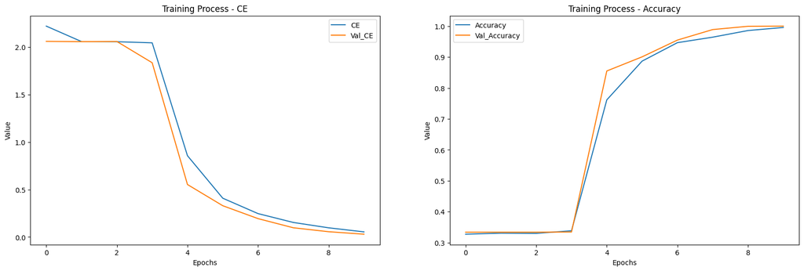

```python
# Φορτωση του module pyplot της βιβλιοθήκης matplotlib και ορισμος του "ψευδώνυμού" του με όνομα plt
import matplotlib.pyplot as plt

# Δημιουργία γραφήματος που θα έχει 2 υπογραφήματα το ένα δίπλα στο άλλο
fig, axis = plt.subplots(nrows=1,ncols=2, figsize=(20,6))

# Δημιουργία του πρώτου γραφήματος (αριστερά)
axis[0].plot(history.epoch, history.history['loss']) # δημιουργία γραφικής παράστασης Cross Entropy εκπαίδευσης
axis[0].plot(history.epoch, history.history['val_loss']) # δημιουργία γραφικής παράστασης Cross Entropy επαλήθευσης
axis[0].set_xlabel("Epochs") # ορισμός τίτλου οριζόντιου άξονα
axis[0].set_ylabel("Value") # ορισμός τίτλου κατακόρυφου άξονα
axis[0].legend(["CE", "Val_CE"]) # ορισμός υπομνήματος
axis[0].set_title("Training Process - CE") # ορισμός τίτλου γραφήματος

# Δημιουργία του δεύτερου γραφήματος (δεξιά) - H ίδια διαδικασία αλλα για την Ακρίβεια
axis[1].plot(history.epoch, history.history['accuracy'])
axis[1].plot(history.epoch, history.history['val_accuracy'])
axis[1].set_xlabel("Epochs")
axis[1].set_ylabel("Value")
axis[1].legend(["Accuracy", "Val_Accuracy"])
axis[1].set_title("Training Process - Accuracy")
plt.show()
```